# Midterm

Rachel Cardarelli

November 25, 2019

## Import the Data

```r
# library(haven)
# hospital <- read_sas("C:/Users/student/Documents/R Programming/hdd0318cy.sas7bdat", NULL)
```

## Selecting variables

- parsed through the variables individually by making frequency tables
- automatically removed variablesthat were more than 50% missing
- removed charge-related variables, all of the poa (b/c just asking if form on hand), fillers, and correlated variables (like race and ethnic, because all information was in raceethn variable and it didn’t have too many missing)

```r
# library(tidyverse)
# hospital2 <- subset(hospital, select = -c(payfix,filler1,filler2,filler3,filler4, filler6a, filler7, filler8, dx2:dx25, dispub92, bwght, b_wt, px1:px25, ancilar, campus, er_fee, er_chrg, er_mode, obs_chrg, obs_hour, psycchrg, poa1:poa25, drg, ethnic, race, trandb, randbg, randbs, orr, anes, seq, lab, dtest, ther, blood, phar, other, patcon, tot, total, yoa, yod, moa, admtype, asource, ecodepoa))
# hospital2$los <- hospital$los
```

## Cleaning and Preprocessing

- lots of recoding

```r
# #method of payment variable
# hospital3 <- hospital2 %>% mutate(Method_of_Pmt = case_when(
#   .$pay_ub92 == 15 | .$pay_ub92 == 10 ~ "Non-Profit",
#   .$pay_ub92 == 13 ~ "Self Pay",
#   .$pay_ub92 == 12 ~ "Other",
#   .$pay_ub92 == 11 ~ "Worker's Comp",
#   .$pay_ub92 == 6 | .$pay_ub92 == 7 | .$pay_ub92 == 8 | .$pay_ub92 == 9 ~ "Insurance",
#   .$pay_ub92 == 1 | .$pay_ub92 == 2 | .$pay_ub92 == 3 | .$pay_ub92 == 4 | .$pay_ub92 == 5 ~ "Medicaid/Medicare"
# )) %>% select(-pay_ub92)
#
# #age
# hospital3 <- hospital3 %>% mutate(Age = case_when(
#   .$age > 122 ~ 122,
#   TRUE ~ .$age
# )) %>% select(-age)
#
# #los
# hospital3 <- hospital3 %>% mutate(LOS = case_when(
#   .$los < 0 ~ 0,
#   TRUE ~ .$los)) %>% select(-los)
#
# #sex
# hospital3 <- hospital3 %>% mutate(Sex = case_when(
#   .$sex == 1 ~ "Male",
#   .$sex == 2 ~ "Female")) %>% select(-sex)
#
# #race_ethn
# hospital3 <-  hospital3 %>% mutate(Race_Ethn = case_when(
#   .$raceethn == 1 ~ "White, not Hispanic",
#   .$raceethn == 2 ~ "Black, not Hispanic",
#   .$raceethn == 3 ~ "Asian, not Hispanic",
#   .$raceethn == 4 ~ "American Indian, not Hispanic",
#   .$raceethn ==   5 ~ "Native Hawaiian, not Hispanic",
#   .$raceethn == 6 ~ "Other, not Hispanic",
#   .$raceethn ==   7 ~ "Hispanic, all races"
# )) %>% select(-raceethn)
#
# #hospital_name
# hospital3 <-  hospital3 %>% mutate(Hospital_Name = case_when(
#   .$provider == 7201 ~ "Newport",
#   .$provider == 7202 ~ "St. Joseph Health Services of RI",
#   .$provider == 7203 ~ "Memorial",
#   .$provider == 7204 ~ "Miriam",
#   .$provider == 7205 ~ "Rhode Island Hospital",
#   .$provider == 7206 ~ "Roger Williams",
#   .$provider == 7209 ~ "South County",
#   .$provider == 7210 ~ "Kent County",
#   .$provider == 7211 ~ "Westerly",
#   .$provider == 7212 ~ "Rehab of RI",
#   .$provider == 7213 ~ "Landmark Medical Center",
#   .$provider == 7214 ~ "Women and Infants",
#   .$provider == 7215 ~ "Bradley",
#   .$provider == 7216 ~ "Butler")) %>% select(-provider)
#
# #season
# hospital3 <-  hospital3 %>% mutate(Season = case_when(
#   .$mod == c(3:5) ~ "Spring",
#   .$mod == c(5:8) ~ "Summer",
#   .$mod == c(8:11) ~ "Fall",
#   .$mod == c(1:2) | .$mod == 12 ~ "Winter")) %>% select(-mod)
#
# library(DescTools)
# #diagnosis1 - if first two digits in code was 0 or 00, then the number was less than 100, convert all to icd-9 format, only need first three digits of numbers to put them in bins
# #hospital3 <- hospital3 %>% order_by(dx1)
#
# hospital3 <-  hospital3 %>% mutate(Diagnosis = case_when(
#  StrLeft(.$dx1,1) == "0" ~ "100",
#  StrLeft(.$dx1,1) == "A" ~ "100",
#  StrLeft(.$dx1,1) == "B" ~ "100",
#  StrLeft(.$dx1,1) == "C" ~ "140",
#  StrLeft(.$dx1,1) == "D" & as.numeric(substr(.$dx1,2,2)) %in% c(0:4) ~ "140",
#  StrLeft(.$dx1,1) == "D" & as.numeric(substr(.$dx1,2,2) %in% c(5:8)) ~ "280",
#  StrLeft(.$dx1,1) == "E" ~ "240",
#  StrLeft(.$dx1,1) == "F" ~ "290",
#  StrLeft(.$dx1,1) == "G" ~ "320",
#  StrLeft(.$dx1,1) == "I" ~ "390",
#  StrLeft(.$dx1,1) == "J" ~ "460",
#  StrLeft(.$dx1,1) == "K" ~ "520",
#  StrLeft(.$dx1,1) == "N" ~ "580",
#  StrLeft(.$dx1,1) == "O" ~ "630",
#  StrLeft(.$dx1,1) == "L" ~ "680",
#  StrLeft(.$dx1,1) == "M" ~ "710",
#  StrLeft(.$dx1,1) == "Q" ~ "740",
#  StrLeft(.$dx1,1) == "P" ~ "760",
#  StrLeft(.$dx1,1) == "S" ~ "800",
#  StrLeft(.$dx1,1) == "T" ~ "800",
#  StrLeft(.$dx1,1) == "V" ~ "1000",
#  StrLeft(.$dx1,1) == "X" ~ "1000",
#  StrLeft(.$dx1,1) == "Y" ~ "1000",
#  StrLeft(.$dx1,1) == "R" ~ "1001",
#  StrLeft(.$dx1,1) == "Z" ~ "1002",
#  StrLeft(.$dx1,1) == "H" ~ "1003",
#  TRUE ~ StrLeft(.$dx1,3))) %>% select(-dx1)
#
# hospital3$Diagnosis <- as.numeric(hospital3$Diagnosis)
#
# hospital3 <- hospital3 %>% mutate(Diagnosis1 = case_when(
#   Diagnosis %in% c(100:139) ~ "Infectious and Parasitic Diseases",
#   Diagnosis %in% c(140:239) ~ "Neoplasms",
#   Diagnosis %in% c(240:279) ~ "Endocrine, Nutritional and Metabolic Diseases, and Immunity Disorders",
#   Diagnosis %in% c(280:289) ~ "Diseases of the Blood and Blood-Forming Organs",
#   Diagnosis %in% c(290:319) ~ "Mental Disorders",
#   Diagnosis %in% c(320:389) ~ "Diseases of the Nervous System and Sense Organs",
#   Diagnosis %in% 1003 ~ "Diseases of the Eye or Ear",
#   Diagnosis %in% c(390:459) ~ "Diseases of the Circulatory System",
#   Diagnosis %in% c(460:519) ~ "Diseases of the Respiratory System",
#   Diagnosis %in% c(520:579) ~ "Diseases of the Digestive System",
#   Diagnosis %in% c(580:629) ~ "Diseases of the Genitourinary System",
#   Diagnosis %in% c(630:679) ~ "Complications of Pregnancy, Childbirth and Puerperium",
#   Diagnosis %in% c(680:709) ~ "Diseases of the Skin and Subcultaneous System",
#   Diagnosis %in% c(710:739) ~ "Diseases of the Musculoskeletal System and Connective Tissue",
#   Diagnosis %in% c(740:759) ~ "Congenital Anomalies",
#   Diagnosis %in% c(760:779) ~ "Certain Conditions Originating in the Perinatal Period",
#   Diagnosis %in% c(800:999) ~ "Injury and Poisoning",
#   Diagnosis == 1000 ~ "External Causes",
#   Diagnosis == 1001 ~ "Not Classified",
#   Diagnosis == 1002 ~ "Misc. Factors Affecting Treatment"
#     )) %>% select(-Diagnosis)
```

## Classification Problem

- wrote cleaned data to csv to save time
- Length of stay is a result of many factors: severity of illness, size of the payment, etc.

```r
library(readr)
library(tidyverse)
hospital3 <- read_csv("hospital3.csv")
hospital3 <- hospital3 %>% select(-X1)
hospital3$Sex <- as.factor(hospital3$Sex)
hospital3$Method_of_Pmt <- as.factor(hospital3$Method_of_Pmt)
hospital3$Race_Ethn <- as.factor(hospital3$Race_Ethn)
hospital3$Hospital_Name <- as.factor(hospital3$Hospital_Name)
hospital3$Season <- as.factor(hospital3$Season)
hospital3$Diagnosis1 <- as.factor(hospital3$Diagnosis1)

#mean stay is 5 days, let's predict length of stay > 1 week
mean(hospital3$LOS, na.rm = TRUE)
```

```
## [1] 5.000655
```

```r
hospital3 <- hospital3 %>% mutate(target = case_when(
  .$LOS <= 7 ~ "0",
  .$LOS > 7 ~ "1"))

hospital3$target <- as.factor(hospital3$target)
```

## Density of Age

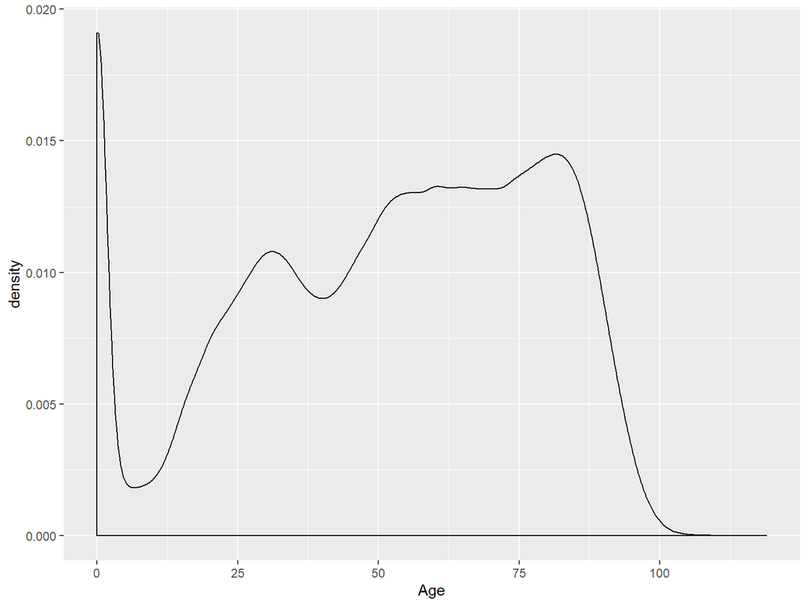

```r
library(ggplot2)
hospital5 <- hospital3 %>% select(-Method_of_Pmt) %>% drop_na()
ggplot(hospital5, aes(Age)) + geom_density()
```

## Distribution of Sex

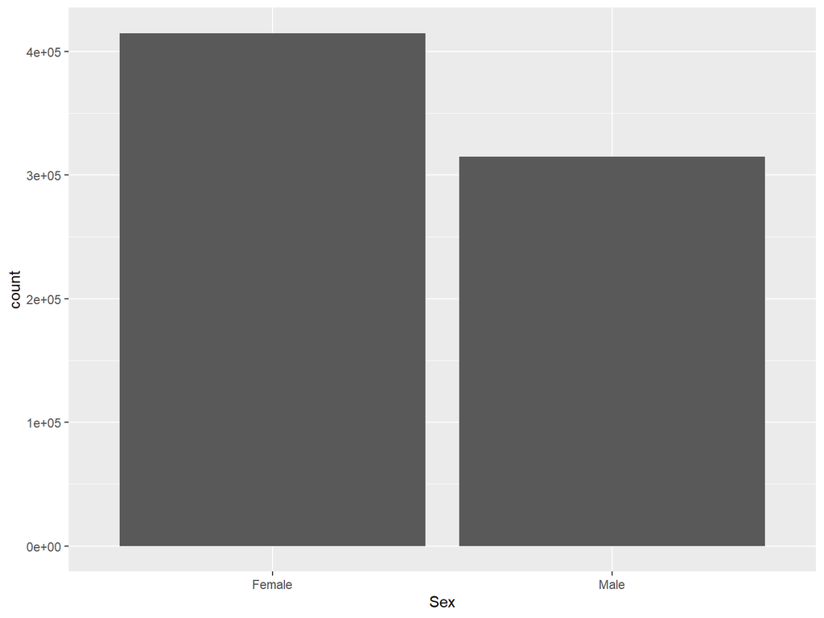

```r
ggplot(hospital5, aes(Sex)) + geom_bar(stat="count")
```

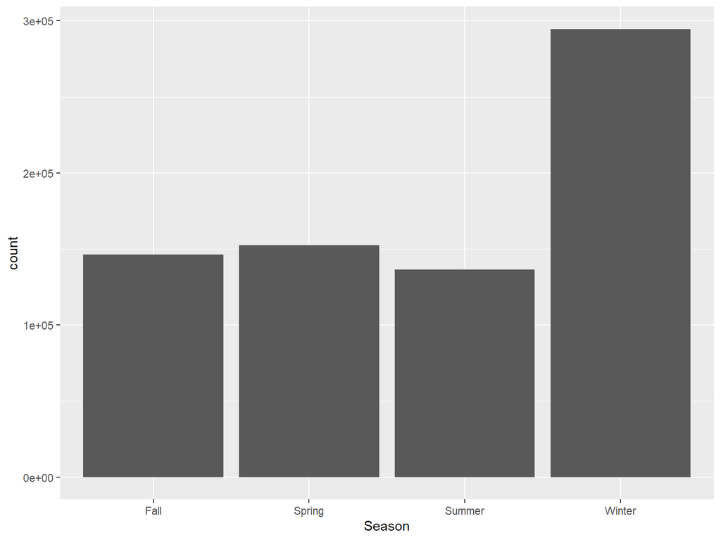

```r
ggplot(hospital5, aes(Season)) + geom_bar(stat="count")
```

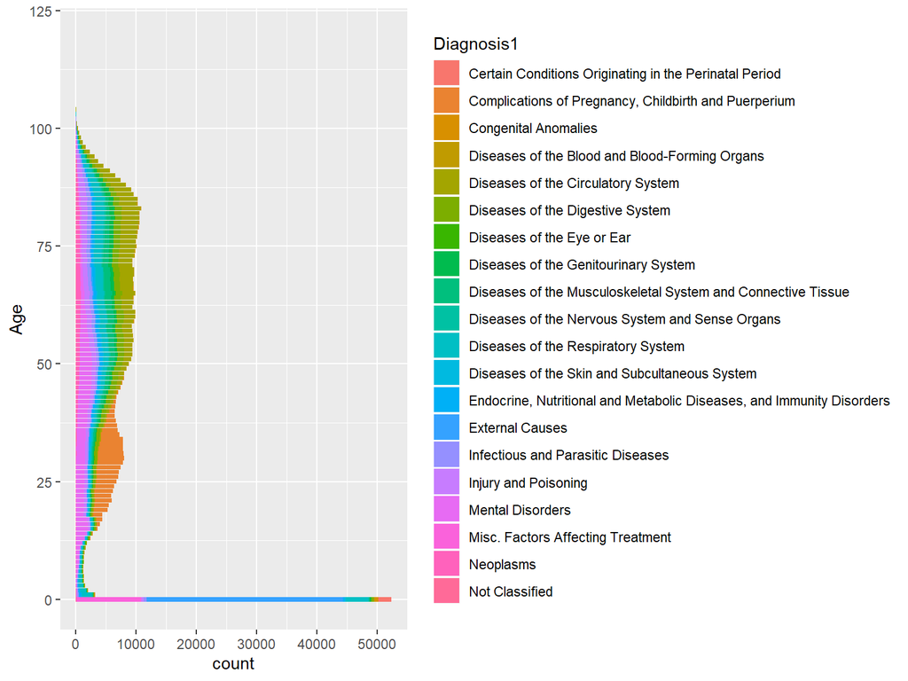

```r
ggplot(hospital5, aes(Age, fill = Diagnosis1)) + geom_bar() + coord_flip()
```

## Graph of Distribution of Age by Sex

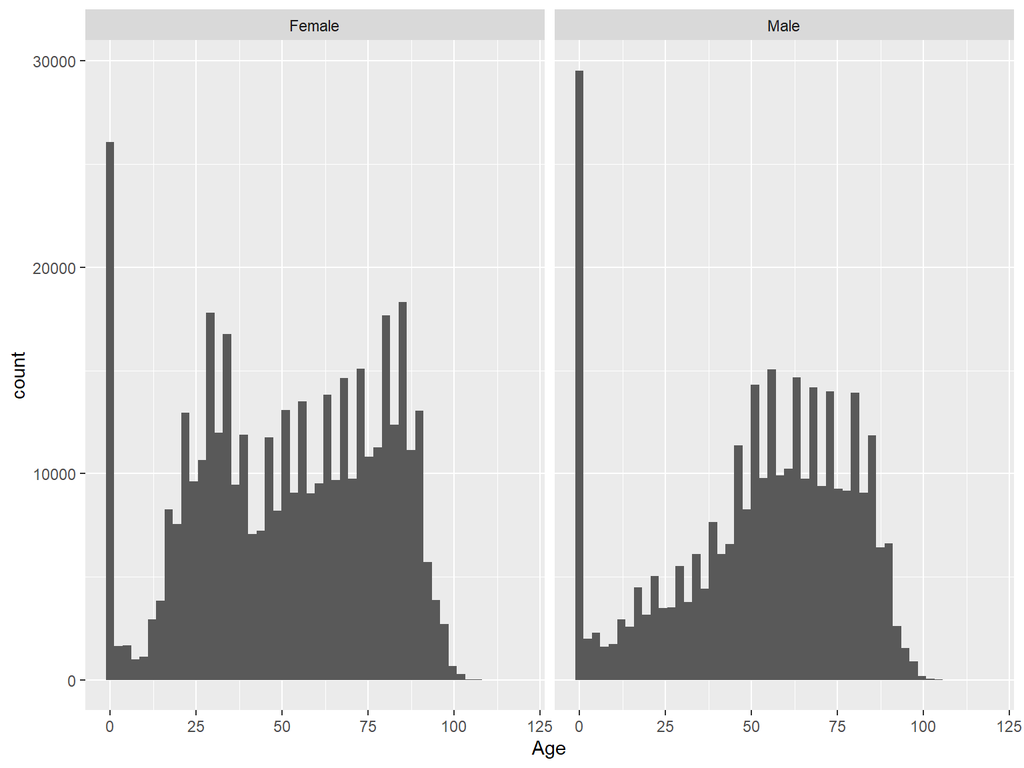

```r
ggplot(hospital5, aes(Age)) + geom_histogram(bins = 50) + facet_grid(~Sex)
```

## Graph of Distribution of Diagnosis by Sex

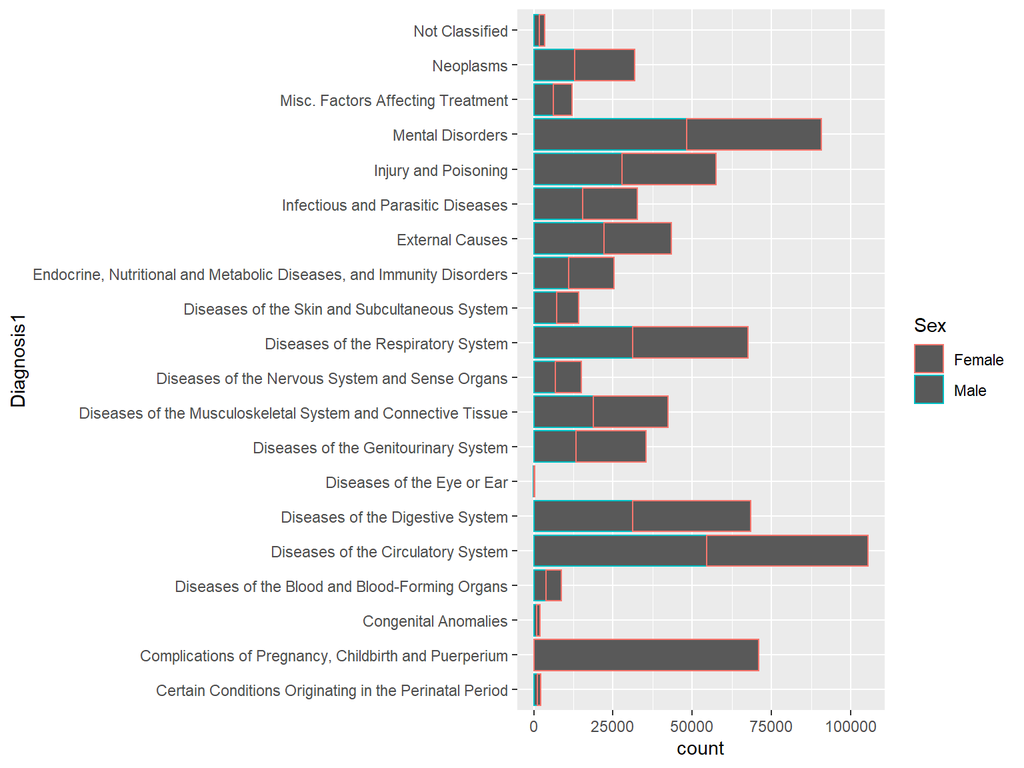

```r
ggplot(hospital5, aes(Diagnosis1, color = Sex)) + geom_histogram(stat="count") + coord_flip()
```

## Distribution of Age by Race/Ethnicity Colored by Sex

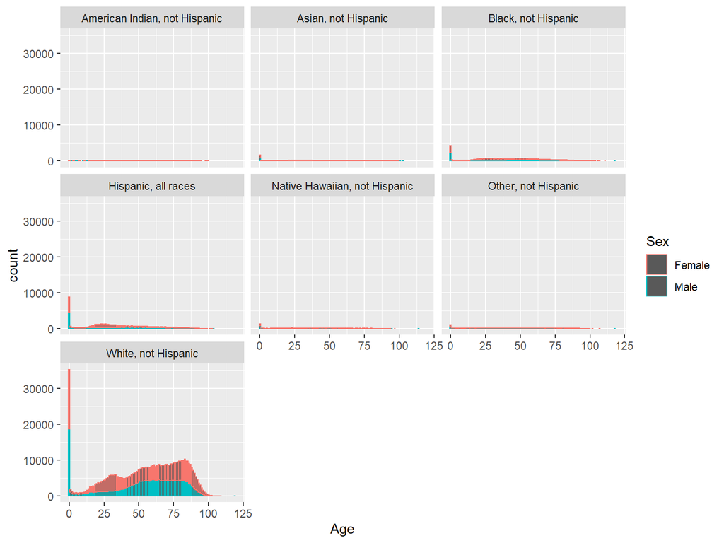

```r
ggplot(hospital5, aes(Age, color = Sex)) + geom_bar() + facet_wrap(~Race_Ethn)
```

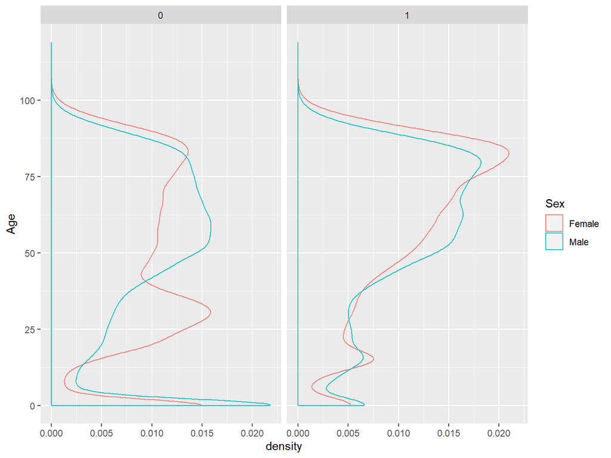

```r
ggplot(hospital5, aes(Age, color = Sex)) + geom_density() + coord_flip() + facet_wrap(~target)
```

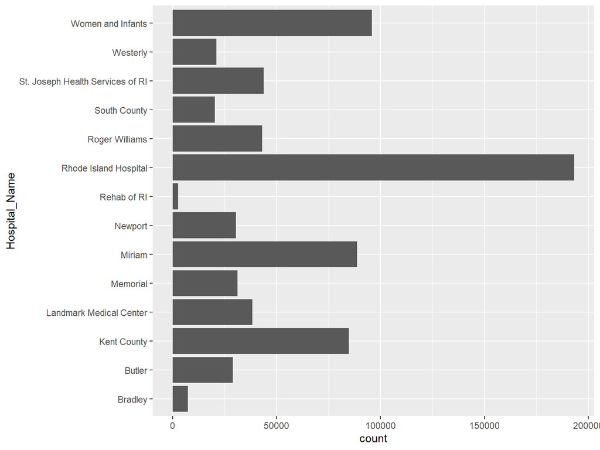

```r
ggplot(hospital5, aes(Hospital_Name)) + geom_bar(stat="count") + coord_flip()
```

## Graph of Diagnosis Grouped By Length of Stay

- pregnancies usually do not lead to a length of stay greater than 1 week

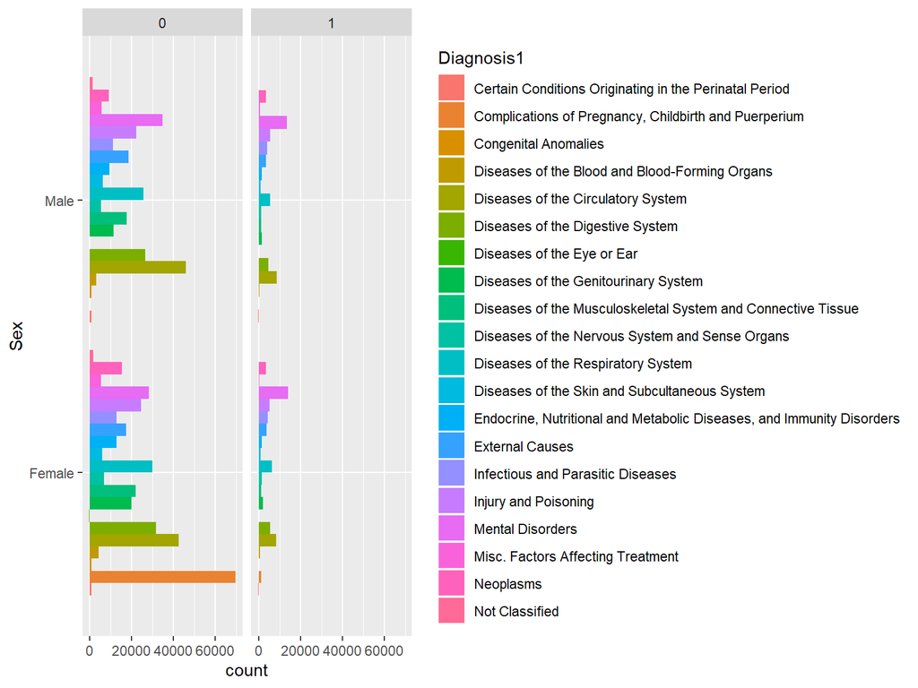

```r
ggplot(hospital5, aes(Sex, ..count..)) + geom_bar(aes(fill = Diagnosis1), position = "dodge") + facet_grid(~Race_Ethn) + facet_wrap(~target)+ coord_flip()
```

## Partitioning For Model

```r
hospital4 <- hospital3 %>% select(-Season, -Method_of_Pmt, -LOS) %>% drop_na()
hospital4 <- hospital4[sample(1:nrow(hospital4), 20000),]

#imbalanced
prop.table(table(hospital4$target))
```

```
##
##      0      1
## 0.8397 0.1603
```

```r
library(caret)
#partitioning the data
index = createDataPartition(y=hospital4$target, p=0.8, list=FALSE)

train = hospital4[index,]
test = hospital4[-index,]

#undersampling on training
train0 = train[train$target == "0",]
train1 = train[train$target == "1",]
n0 = nrow(train0)
n1 = nrow(train1)
train00 = train0[sample(1:n0, n1),]
train_under = rbind(train00, train1)

#checked to make sure more points in undersampled training than in testing
length(test$target) < length(train_under$target)
```

```
## [1] TRUE
```

## ranger

-mtry: Number of variables to possibly split at in each node. Default is the (rounded down) square root of the number variables. -min.node.size: Minimal node size. -splitrule: Split rule. -best with min.node.size = 2

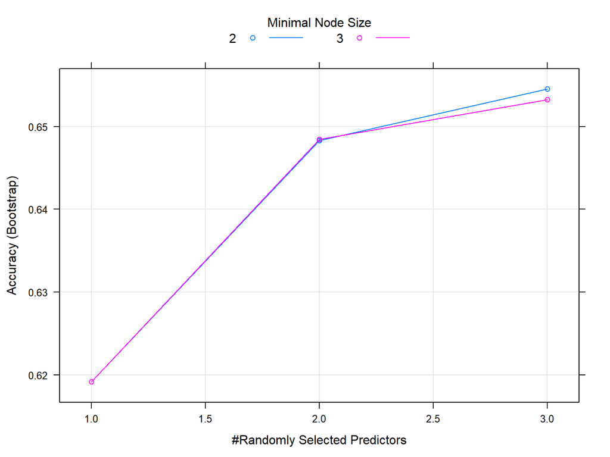

```r
myGrid = expand.grid(mtry = c(1:3), splitrule = c("gini"), min.node.size = c(2,3))
model_under = train(target~., data = train_under, method = "ranger", tuneGrid = myGrid)
pred = predict(model_under, test)
accuracy = confusionMatrix(table(pred, test$target))$overall[[1]]
ba = confusionMatrix(table(pred, test$target))$byClass[[11]]
plot(model_under)
```

```r
ba
```

```
## [1] 0.6532877
```

## adaboost

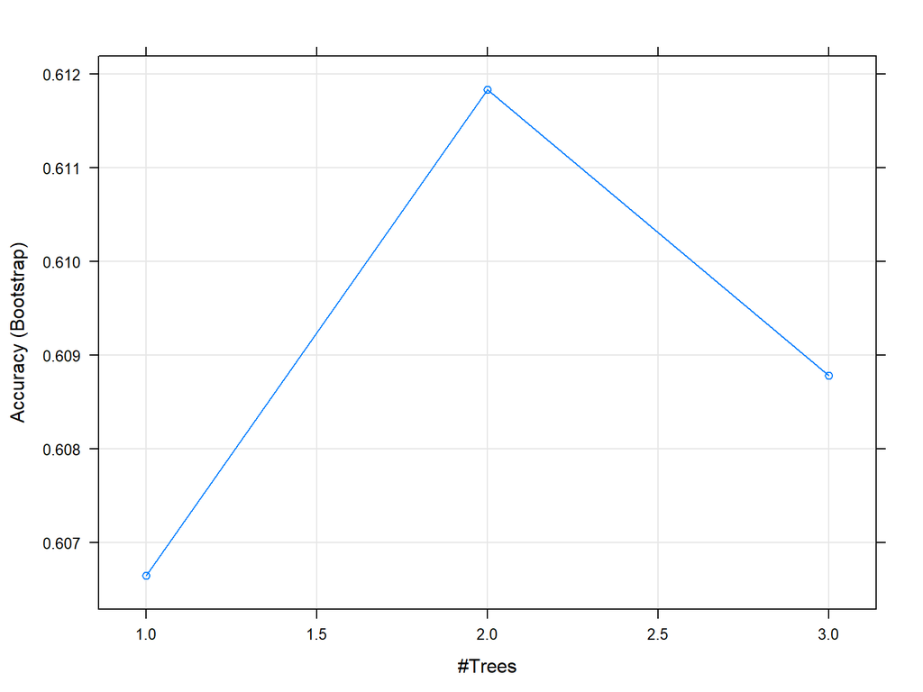

```r
library(fastAdaboost)
#the tuning parameter for adaboost are nIter and method
myGrid = expand.grid(nIter = c(1:3), method = "ada")
model_under = train(target~., data = train_under, method = "adaboost", tuneGrid = myGrid)
pred = predict(model_under, test)
accuracy = confusionMatrix(table(pred, test$target))$overall[[1]]
ba = confusionMatrix(table(pred, test$target))$byClass[[11]]
plot(model_under)
```

```r
ba
```

```
## [1] 0.6153468
```

## rpart1SE

- No tuning parameters

```r
model_under = train(target~., data = train_under, method = "rpart1SE")
pred = predict(model_under, test)
accuracy = confusionMatrix(table(pred, test$target))$overall[[1]]
ba = confusionMatrix(table(pred, test$target))$byClass[[11]]
ba
```

```
## [1] 0.6360904
```

## rpart

- CP: complexity parameter
- documentation “The main role of this parameter is to save computing time by pruning off splits that are obviously not worthwhile. Essentially,the user informs the program that any split which does not improve the fit by cp will likely be pruned off by cross-validation, and that hence the program need not pursue it.”

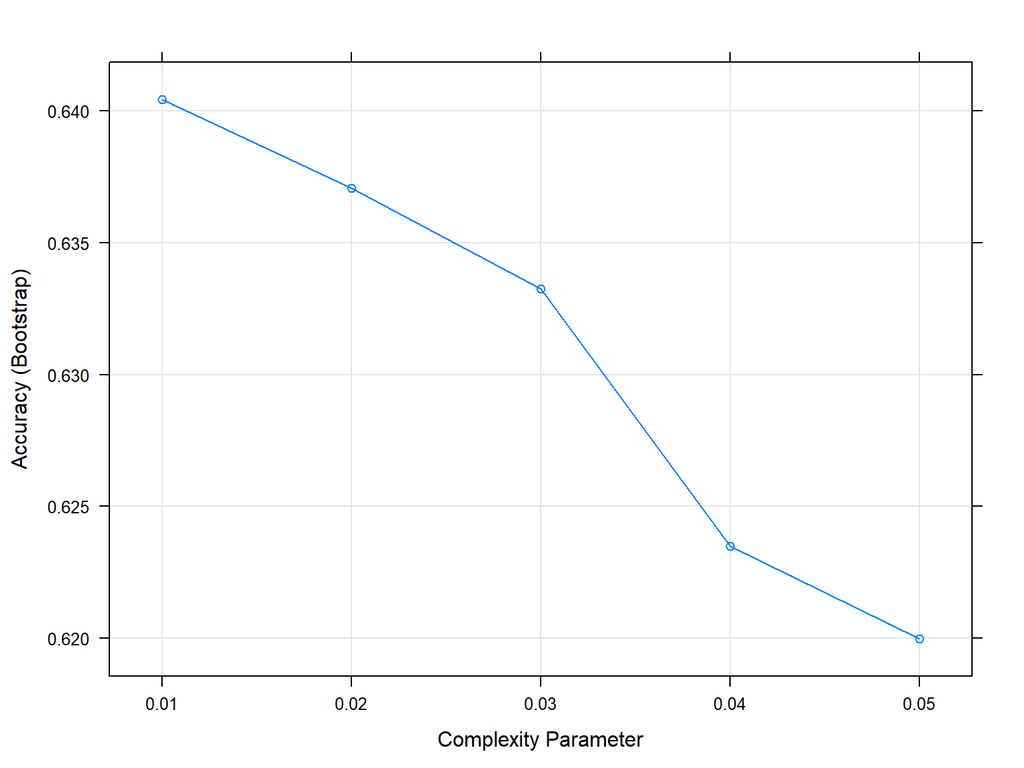

```r
myGrid = expand.grid(cp=seq(.01,.05,by=.01))
model_under = train(target~., data = train_under, method = "rpart",tuneGrid = myGrid)
pred  = predict(model_under, test)
accuracy = confusionMatrix(table(pred, test$target))$overall[[1]]
ba = confusionMatrix(table(pred, test$target))$byClass[[11]]
plot(model_under)
```

```r
ba
```

```
## [1] 0.6360904
```

## rpart2

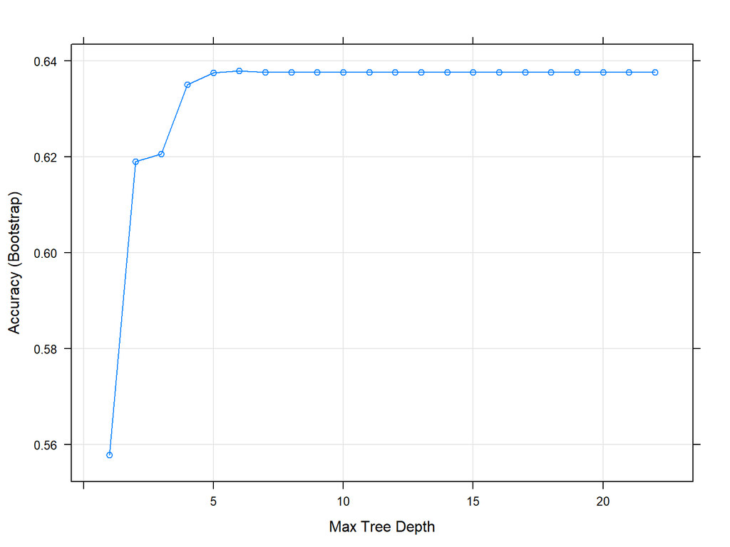

```r
myGrid = expand.grid(maxdepth = c(1:22))
model_under = train(target~., data = train_under, method = "rpart2",tuneGrid = myGrid)
pred  = predict(model_under, test)
accuracy = confusionMatrix(table(pred, test$target))$overall[[1]]
ba = confusionMatrix(table(pred, test$target))$byClass[[11]]
plot(model_under)
```

```r
ba
```

```
## [1] 0.6360904
```